# Group 1 Project 2 Report

Becky Desrosiers, Alexandra Ferentinos, Abner Casillas-Colon, John Le

2023-11-19

# Section 1: High-level summary

This report investigates the question: What factors affect the price of a home? Section 4 displays visualizations of the predictor variables in question. Through regression analysis, Section 5 of this report finds that square footage, grade, and build year can be used to create a linear model that explains 61% of variation in home prices. There will always be variation due to fringe factors and random chance, but our model is useful when compared to models with fewer predictors and maintains simplicity so as to remain interpretable.

Section 6 displays visualizations related to our second question of interest: Can we predict whether a house is on a waterfront based on other qualities? We found in Section 7 that waterfront status can be predicted with a 97.8% accuracy rate using square footage, number of bedrooms and bathrooms, condition, grade, and the square footage of the nearest 15 neighbors as predictors. Based on our analysis, our model performs significantly better than random guessing, and can be used to quantify the relationship between a home’s waterfront status and the other factors.

# Section 2: Description of data and variables

This data describes observations of houses sold in King County, Washington between May 2014 and May 2015. It contains 16 variables that we will utilize for our analysis that are listed below. Two variables that are not included in our analysis of the dataset are ID and Date which represent a unique ID for the home and Date which the home was sold respectively.

**Default Variables:**

- *price*: The price of the home sold.
- *bedrooms*: The number of bedrooms that the house has.
- *bathrooms*: The number of bathrooms that the house has.
- *sqft_living*: The square footage of the interior living space for the house.
- *sqft_lot*: The square footage of the land space of the house.
- *floors*: The number of floors the house has.
- *waterfront*: A variable indicating whether the house has a view of the waterfront or not.
- *view*: A variable denoting the quality of the view that the house has ranging from 0 to 4.
- *condition*: A factor variable ranging from 1 to 5 indicating the state that the house is currently in.
- *grade*: A factor variable for the quality of the homes initial construction with 1-3 indicates quality that is below expectations, 7 meeting average expectations, and 11-13 having a high quality of construction.
- *sqft_above*: The interior square footage of the home that is above ground level.
- *sqft_basement*: The interior square footage of the home that is below ground level.
- *yr_built*: The year in which the house was built.
- *yr_renovated*: The year the house was renovated if applicable, otherwise zero.
- *sqft_living15*: The square footage of the interior living space for the nearest 15 neighbor homes.
- *sqft_lot15*: The square footage of the land space for the nearest 15 neighbor homes.

**Created Variables:**

- *log.y* – This variable is the price variable with a log transformation created to correct issues linear assumptions for the model.
- *log.sqft_living* – This variable is the log transformed version of the square foot living space created to correct issues linear assumptions for the model.

# Section 3: Questions of interest

### Question 1: What factors affect the price of a home? Out of all the predictors, which is the best model? Bedrooms, bathrooms, square footage of the house or the property, condition, square footage of above-floor-level space, square footage of basement space, year built, year renovated, and the square footage of the houses and properties of the 15 closest neighbors.

The practical application for the first question will be for a construction company to determine how best to invest their money into a project so that they can sell it for the best price. A buyer may also benefit from the analysis by discerning which attributes can be money-savers or in which attributes (number of bathrooms, number of floors, etc.) they may be able to gain more without spending much more. The response variable for the first question will be price; we are interested in finding which factors most influence the price.

### Question 2: Can we predict whether a house is on a waterfront based on other qualities? Square footage, # bedrooms, # bathrooms, sqft_living15, condition, grade.

We are interested in the second question to find out if there is a significant difference between waterfront properties and non-waterfront properties. We hypothesize that waterfront properties will be higher quality in general (higher square footage, more bedrooms and bathrooms, higher grade), and have neighbors with bigger houses, but perhaps will be in worse condition because of the proximity to water and the risk of flooding. The response variable for the second data set is waterfront status: is it a waterfront property or not? We are interested in the relationship between waterfront status and other attributes, and if waterfront properties tend to have certain attributes.

# Section 4: Question 1 data visualizations

### Univariate visualizations

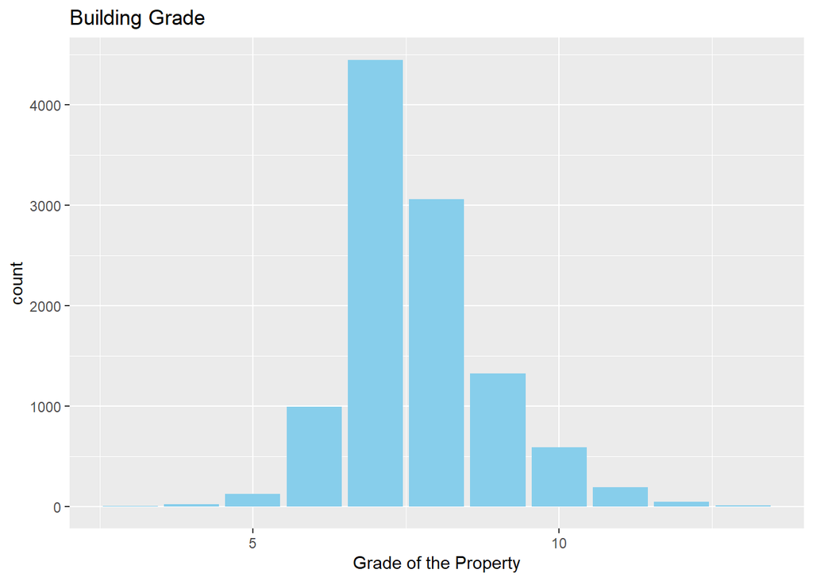

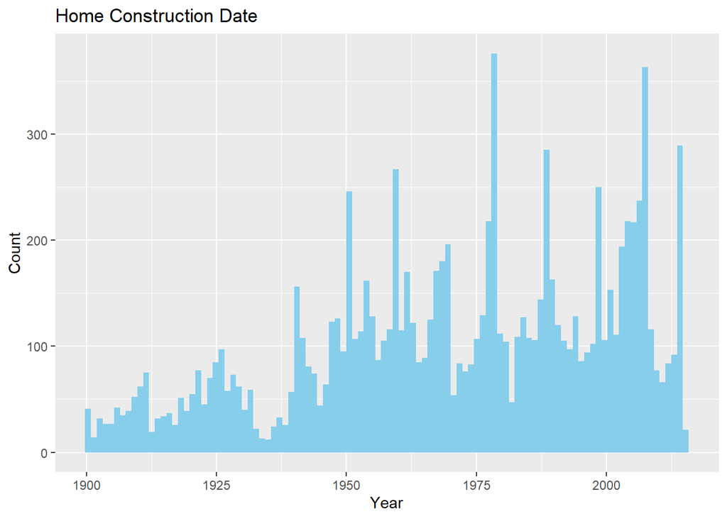

This histogram is created to evaluate the distribution of the construction date of the houses in the dataset. The distribution of the histogram is roughly left skewed, with more observations occurring in recent years. Though the skewness that is present is not necessarily extreme it may still be prudent to examine if the older homes present outsized influence on price when fitting the model. One thing to note is that certain years exhibit high spikes of activity in regular intervals, which appear to be after every 5-10 years. When examining the relationship between price and construction date these high volume points may be worth further scrutiny in case the increased quantity coincided with decreased quality of construction that impacts price.

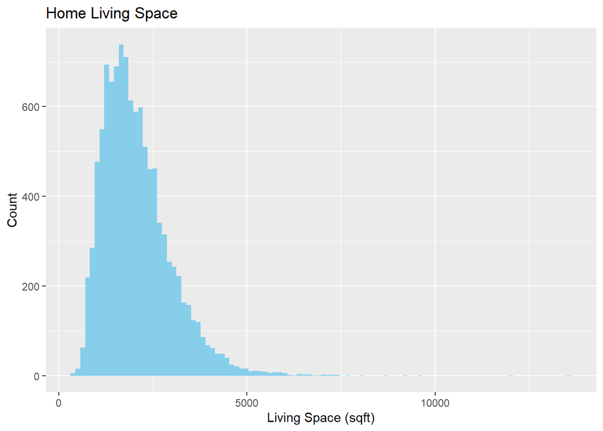

The histogram displays a distribution for the squarefoot living space of the houses within the training data set. Our distribution is right skewed indicating potentially to be on the lookout for outliers on the extreme end that will impact the linearity of the relationship when we conduct our testing. Additionally, if we are to describe our data set we would expect the mean value to be higher than the median and may want to use the median value as a descriptor when discussing how to evaluate the central point of housing living space as a better representation of the data set.

### Bivariate visualizations

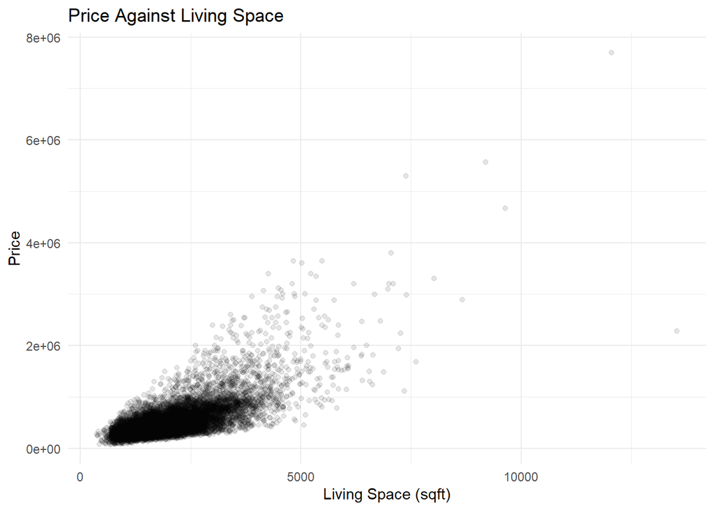

There is a clear positive correlation between the square footage of living space and the price of a house. As the square footage increases, so does the price, which is a common trend in real estate markets. Most of the data points are concentrated in the lower range of square footage and price, indicating that a majority of the houses in this dataset are moderately sized and priced. The plot suggests that as homes increase in square footage, the price does not just increase linearly but may increase at a higher rate. This could imply a premium for larger homes beyond a certain size.

The dense clustering of points at the lower square footage range could make it challenging to distinguish between the price differences among smaller homes. This might necessitate a more detailed analysis or the use of additional variables to understand the pricing structure for these homes. For any given square footage, there is quite a wide variation in price, especially in the higher ranges of square footage. This indicates that other factors may be affecting the price, which we will explore in our analysis. There are several data points which may have high leverage, particularly houses with a large square footage that are priced much higher than the rest. These could represent luxury homes or properties with unique features that significantly increase their value. Also of note is the one point at the high extreme of square footage but mid-price, which could be influential.

### Correlation matrix

```
##               price bedrooms bathrooms sqft_living sqft_lot floors waterfront
## price         1.000    0.299     0.530       0.700    0.081  0.257      0.249
## bedrooms      0.299    1.000     0.505       0.563    0.030  0.170     -0.013
## bathrooms     0.530    0.505     1.000       0.755    0.082  0.495      0.064
## sqft_living   0.700    0.563     0.755       1.000    0.167  0.347      0.090
## sqft_lot      0.081    0.030     0.082       0.167    1.000 -0.007      0.025
## floors        0.257    0.170     0.495       0.347   -0.007  1.000      0.023
## waterfront    0.249   -0.013     0.064       0.090    0.025  0.023      1.000
## view          0.389    0.064     0.192       0.281    0.079  0.032      0.405
## condition     0.043    0.028    -0.127      -0.059    0.002 -0.269      0.033
## grade         0.669    0.349     0.660       0.756    0.101  0.452      0.081
## sqft_above    0.601    0.475     0.685       0.874    0.170  0.520      0.061
## sqft_basement 0.338    0.287     0.297       0.454    0.031 -0.240      0.073
## yr_built      0.053    0.162     0.505       0.317    0.049  0.492     -0.034
## yr_renovated  0.141    0.011     0.051       0.064    0.010  0.011      0.105
## sqft_living15 0.585    0.384     0.571       0.754    0.133  0.278      0.085
## sqft_lot15    0.072    0.025     0.081       0.177    0.710 -0.009      0.029
##                 view condition  grade sqft_above sqft_basement yr_built
## price          0.389     0.043  0.669      0.601         0.338    0.053
## bedrooms       0.064     0.028  0.349      0.475         0.287    0.162
## bathrooms      0.192    -0.127  0.660      0.685         0.297    0.505
## sqft_living    0.281    -0.059  0.756      0.874         0.454    0.317
## sqft_lot       0.079     0.002  0.101      0.170         0.031    0.049
## floors         0.032    -0.269  0.452      0.520        -0.240    0.492
## waterfront     0.405     0.033  0.081      0.061         0.073   -0.034
## view           1.000     0.045  0.248      0.165         0.275   -0.053
## condition      0.045     1.000 -0.146     -0.159         0.170   -0.366
## grade          0.248    -0.146  1.000      0.750         0.180    0.452
## sqft_above     0.165    -0.159  0.750      1.000        -0.036    0.422
## sqft_basement  0.275     0.170  0.180     -0.036         1.000   -0.122
## yr_built      -0.053    -0.366  0.452      0.422        -0.122    1.000
## yr_renovated   0.122    -0.062  0.023      0.031         0.074   -0.225
## sqft_living15  0.275    -0.093  0.713      0.730         0.211    0.332
## sqft_lot15     0.080    -0.001  0.105      0.182         0.030    0.066
##               yr_renovated sqft_living15 sqft_lot15
## price                0.141         0.585      0.072
## bedrooms             0.011         0.384      0.025
## bathrooms            0.051         0.571      0.081
## sqft_living          0.064         0.754      0.177
## sqft_lot             0.010         0.133      0.710
## floors               0.011         0.278     -0.009
## waterfront           0.105         0.085      0.029
## view                 0.122         0.275      0.080
## condition           -0.062        -0.093     -0.001
## grade                0.023         0.713      0.105
## sqft_above           0.031         0.730      0.182
## sqft_basement        0.074         0.211      0.030
## yr_built            -0.225         0.332      0.066
## yr_renovated         1.000         0.002      0.012
## sqft_living15        0.002         1.000      0.177
## sqft_lot15           0.012         0.177      1.000
```

From the correlation matrix values will range from -1, 0, and 1, where proximity to -1 indicates a strong negative correlation and proximity to 1 indicates a strong positive correlation. Additionally, proximity to 0 indicates that there is no correlation.

From the predictors mentioned in Question 1 the following appear to have positive correlations:

- *sqft_living* and *grade* (0.756)
- *sqft_living* and *sqft_above* (0.874)
- *sqft_living* and *sqft_living15* (0.754)
- *bathrooms* and *sqft_living* (0.755)

From the correlation matrix, we also observe that *sqft_basement* has a very low correlation with *price* (0.338). Therefore we will not be including it in our model or investigating it moving forward.

Predictors *condition*, *waterfront*, and *view* will also be dropped from the model and not considered because we can only consider one categorical variable at this point in our schooling, and *grade* is much more highly correlated with *price.* We therefore considered *grade* to be the most significant to the model and it will be the categorical variable that we consider.

### Skipped visualizations

The number of bathrooms, and other sqft measurements are highly correlated with *sqft_living*, so we decided that a visualization for *sqft_living* would be sufficient to represent all of them (with the exception of *sqft_basement*, which was dropped from our investigation). We will keep this in mind when selecting our models because there is likely to be multicollinearity between these predictors, and we will likely only keep one. A similar reasoning combined with low correlation with price caused us to leave the number of bedrooms out of our visualizations as well.

Also dropped from our considerations was the renovation year because very few of the data points actually have a renovation year. We decided that the data relating to *yr_renovated* would be incomplete and possibly misrepresented by the dearth of observations, and that our model would be more useful without it.

# Section 5: Question 1 linear regression

### VIFs

We will use VIFs to investigate multicollinearity in our model. Predictors with high VIFs (>5) may be linear combinations of other predictors, which means that some of them may be dropped without sacrrificing validity in our model. The VIFs from our full model appear below:

```
##      bedrooms     bathrooms   sqft_living      sqft_lot        floors
##         1.566         3.249         7.938         2.032         1.896
##         grade    sqft_above      yr_built sqft_living15    sqft_lot15
##         3.148         6.155         1.647         2.764         2.063
```

### AIC stepwise regression

Akaike information criterion (AIC) is a model selection criterion that increases with model fit and penalizes for extra parameters. We will use stepwise regression based on AIC to investigate which model may be best.

```
## Start:  AIC=276727.5
## price ~ 1
##
##                 Df  Sum of Sq        RSS    AIC
## + sqft_living    1 6.9989e+14 7.2999e+14 269465
## + grade          1 6.3946e+14 7.9042e+14 270324
## + sqft_above     1 5.1621e+14 9.1366e+14 271890
## + sqft_living15  1 4.9009e+14 9.3979e+14 272194
## + bathrooms      1 4.0141e+14 1.0285e+15 273169
## + bedrooms       1 1.2812e+14 1.3018e+15 275715
## + floors         1 9.4239e+13 1.3356e+15 275993
## + sqft_lot       1 9.2824e+12 1.4206e+15 276659
## + sqft_lot15     1 7.4948e+12 1.4224e+15 276673
## + yr_built       1 4.0675e+12 1.4258e+15 276699
## <none>                        1.4299e+15 276728
##
## Step:  AIC=269464.5
## price ~ sqft_living
##
##                 Df  Sum of Sq        RSS    AIC
## + grade          1 6.5413e+13 6.6458e+14 268452
## + yr_built       1 4.5003e+13 6.8499e+14 268779
## + bedrooms       1 1.8716e+13 7.1127e+14 269186
## + sqft_living15  1 1.1212e+13 7.1878e+14 269299
## + sqft_lot15     1 3.8778e+12 7.2611e+14 269409
## + sqft_lot       1 1.9327e+12 7.2806e+14 269438
## + sqft_above     1 6.9126e+11 7.2930e+14 269456
## + floors         1 3.2954e+11 7.2966e+14 269462
## <none>                        7.2999e+14 269465
## + bathrooms      1 1.1974e+10 7.2998e+14 269466
## - sqft_living    1 6.9989e+14 1.4299e+15 276728
##
## Step:  AIC=268452.1
## price ~ sqft_living + grade
##
##                 Df  Sum of Sq        RSS    AIC
## + yr_built       1 1.0155e+14 5.6303e+14 266662
## + sqft_above     1 1.0432e+13 6.5415e+14 268283
## + bedrooms       1 1.0326e+13 6.5425e+14 268285
## + floors         1 4.1154e+12 6.6046e+14 268387
```

[output cut: 108 more lines]

```
## price ~ sqft_living + grade + yr_built + bedrooms + bathrooms +
##     sqft_lot15 + sqft_living15 + floors + sqft_above
##
##                 Df  Sum of Sq        RSS    AIC
## <none>                        5.3834e+14 266190
## + sqft_lot       1 1.7151e+09 5.3834e+14 266192
## - sqft_above     1 1.6350e+12 5.3997e+14 266220
## - sqft_lot15     1 1.7807e+12 5.4012e+14 266223
## - floors         1 2.3284e+12 5.4067e+14 266234
## - sqft_living15  1 2.8462e+12 5.4119e+14 266245
## - bathrooms      1 6.1382e+12 5.4448e+14 266310
## - bedrooms       1 1.1762e+13 5.5010e+14 266421
## - sqft_living    1 4.0314e+13 5.7865e+14 266968
## - grade          1 7.8221e+13 6.1656e+14 267654
## - yr_built       1 9.9907e+13 6.3825e+14 268027
```

```
##
## Call:
## lm(formula = price ~ sqft_living + grade + yr_built + bedrooms +
##     bathrooms + sqft_lot15 + sqft_living15 + floors + sqft_above,
##     data = train_lin)
##
## Coefficients:
##   (Intercept)    sqft_living          grade       yr_built       bedrooms
##     7.464e+06      1.860e+02      1.281e+05     -4.224e+03     -4.368e+04
##     bathrooms     sqft_lot15  sqft_living15         floors     sqft_above
##     5.527e+04     -4.692e-01      3.945e+01      3.731e+04     -3.698e+01
```

From the stepwise regression, the model with the best AIC includes every predictor except for *sqft_lot.* That seems a little overcomplicated, so we will investigate another model selection criterion, BIC.

### BIC

Bayesian information criterion (BIC) is a model selection criterion that increases with model fit and penalizes for extra parameters. We are looking for small values with this criterion: the smaller, the better.

```
## [1] -10439.526 -10425.354 -10395.775 -10365.423 -10189.577 -10034.164  -8251.598
## [8]  -7246.417
```

The best model based on BIC would be the first one listed here, with coefficients

```
## (Intercept) sqft_living
## -33083.8488    275.1588
```

However, the first 3 models all have similarly very small BIC’s, so it is worth seeing which predictors are included in those as well:

```
## [[1]]
## (Intercept) sqft_living
## -33083.8488    275.1588
##
## [[2]]
##  (Intercept)  sqft_living        grade
## -603793.3577     178.1215  100811.1202
##
## [[3]]
##  (Intercept)  sqft_living        grade     yr_built
## 6397661.7060     171.4225  146460.4426   -3722.5860
```

From the BIC, *sqft_living*, *grade*, and *yr_built* may all be valuable to the model and worth exploring. From the VIFs, it seems as though *sqft_living* is able to summarize the other sqft predictors to the extent that they are not worth the added complication of the extra predictor variables. With this preliminary data, we will begin testing models:

### Model 1: price ~ sqft

```
##
## Call:
## lm(formula = price ~ sqft_living, data = train_lin)
##
## Residuals:
##      Min       1Q   Median       3Q      Max
## -1412566  -148286   -24390   106104  4417420
##
## Coefficients:
##               Estimate Std. Error t value Pr(>|t|)
## (Intercept) -33083.849   6164.340  -5.367 8.17e-08 ***
## sqft_living    275.159      2.704 101.776  < 2e-16 ***
## ---
## Signif. codes:  0 '***' 0.001 '**' 0.01 '*' 0.05 '.' 0.1 ' ' 1
##
## Residual standard error: 259900 on 10804 degrees of freedom
## Multiple R-squared:  0.4895, Adjusted R-squared:  0.4894
## F-statistic: 1.036e+04 on 1 and 10804 DF,  p-value: < 2.2e-16
```

From the summary, the model appears very useful because it has very significant f-tests and ANOVA tests. We must check that the regression assumptions are met.

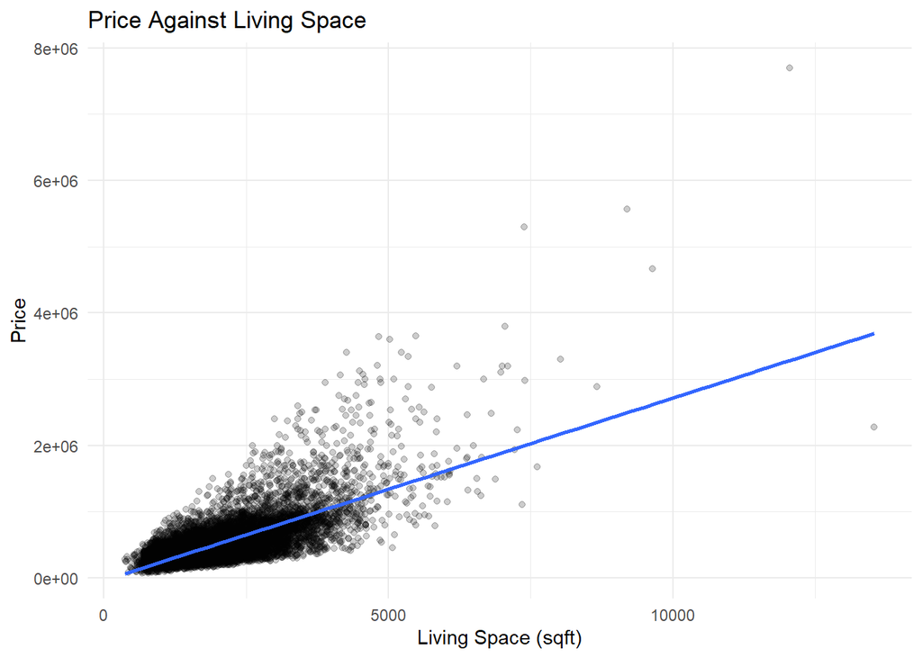

There is a clear relationship, and the variance appears to increase with the predictor. We will explore further by ylooking at the residual plot.

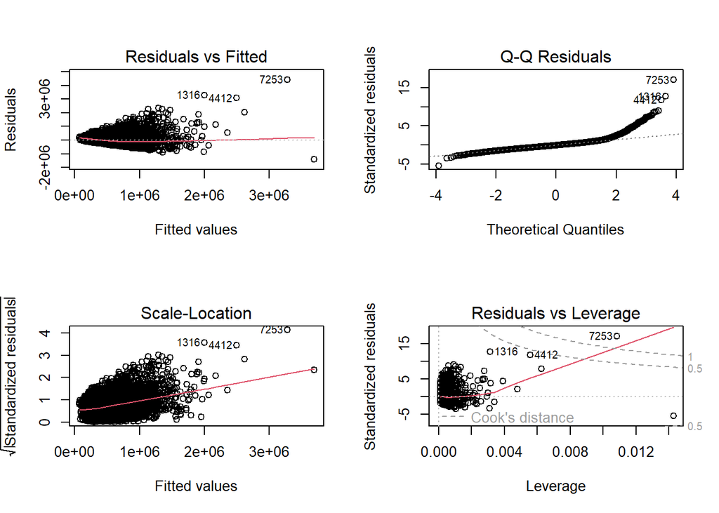

Assumption 2 is met because the residuals average along the x-axis. However, assumption 1 is violated because the variance in residuals increases with x. We need to transform the response variable. We will use a boxcox plot to help determine what transformation to apply.

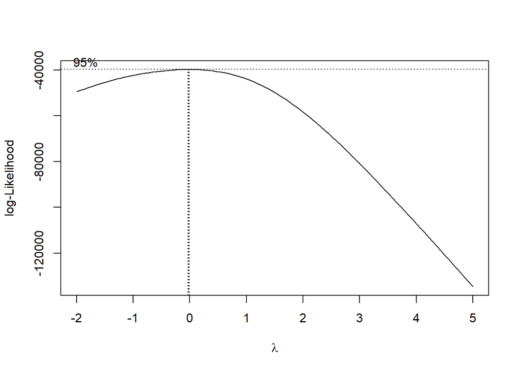

Since 0 is within the critical region on the boxcox plot and is preferred, we will apply a log transformation. *log.y* = log(*y*). We will visualize the relationship again with the new variable.

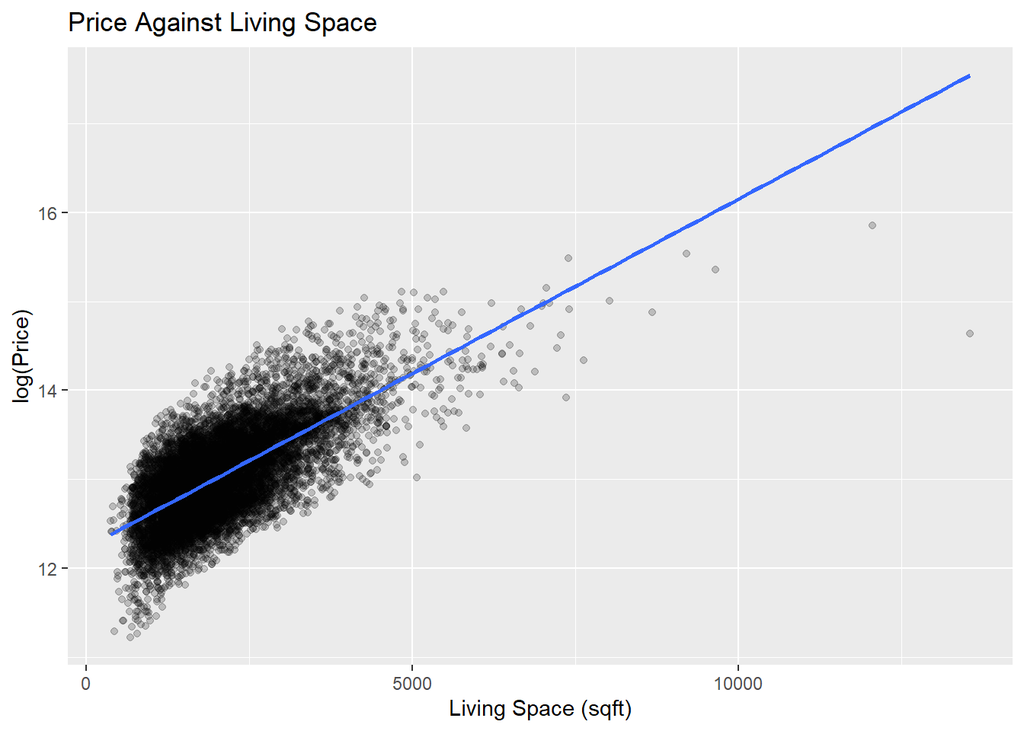

And investigate the new residual plot:

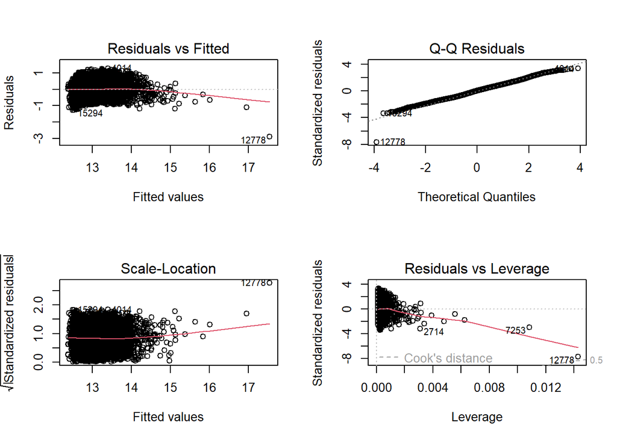

Assumption 1 is now met; the residuals are now evenly scattered around the mean. However, the mean residual skews negative as x grows large, and the scatterplot seems to show a curved relationship, rather than strictly linear, because the majority of the points are below the regression line when x is small and large, but above for moderate levels of x. We will try a log transformation on the predictor variable so that our model can remain interpretable.

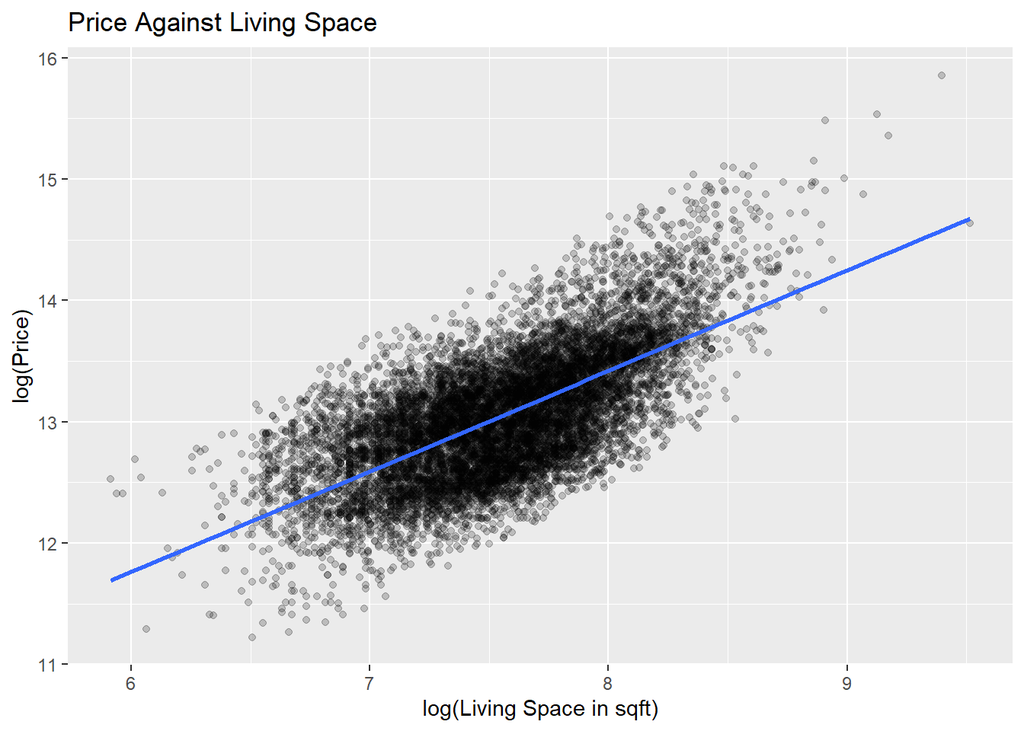

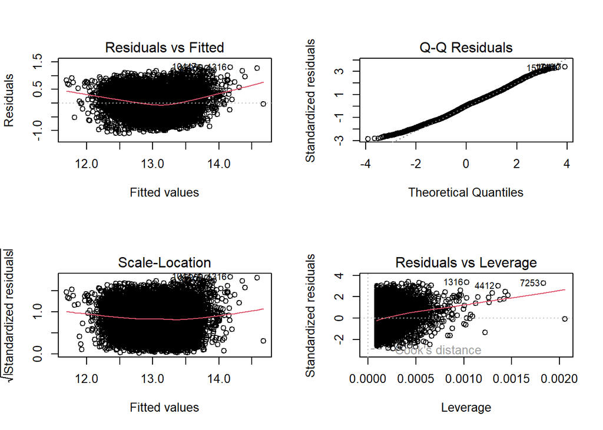

### Model 2: price ~ sqft_living + grade

```
##
## Call:
## lm(formula = price ~ sqft_living + grade, data = train_lin)
##
## Residuals:
##     Min      1Q  Median      3Q     Max
## -757296 -137124  -25785   98616 4846884
##
## Coefficients:
##               Estimate Std. Error t value Pr(>|t|)
## (Intercept) -6.038e+05  1.846e+04  -32.70   <2e-16 ***
## sqft_living  1.781e+02  3.938e+00   45.23   <2e-16 ***
## grade        1.008e+05  3.092e+03   32.61   <2e-16 ***
## ---
## Signif. codes:  0 '***' 0.001 '**' 0.01 '*' 0.05 '.' 0.1 ' ' 1
##
## Residual standard error: 248000 on 10803 degrees of freedom
## Multiple R-squared:  0.5352, Adjusted R-squared:  0.5351
## F-statistic:  6220 on 2 and 10803 DF,  p-value: < 2.2e-16
```

```
## Analysis of Variance Table
##
## Model 1: price ~ sqft_living + grade
## Model 2: price ~ sqft_living
##   Res.Df        RSS Df   Sum of Sq      F    Pr(>F)
## 1  10803 6.6458e+14
## 2  10804 7.2999e+14 -1 -6.5413e+13 1063.3 < 2.2e-16 ***
## ---
## Signif. codes:  0 '***' 0.001 '**' 0.01 '*' 0.05 '.' 0.1 ' ' 1
```

The summary indicates that both *sqft_living* and *grade* are significant predictors of price. Based on the R<sup>2</sup> value, 53.52% of variability in price is explained by this model. Low p-values for both the F-statistic and the ANOVA test indicate the model with both predictors is better than the intercept-only model and our preliminary model with only *sqft_living.* We now look at the residual plot to evaluate if the regression assumptions are met.

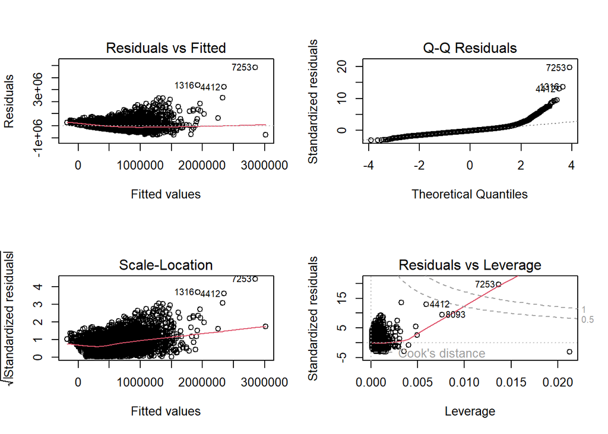

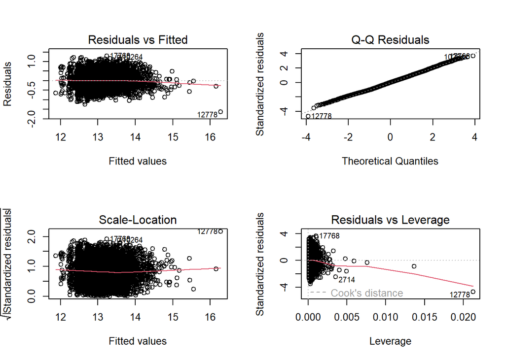

This plot looks much better. Even though our outlier is still skewing the average residual slightly at high levels of the predictor, the residuals are mostly evenly scattered along the x-axis.

We will now compare the two models, both with transformed response variables.

```
##                   AIC      BIC    PRESS
## model2_ystar 8096.937 8126.089 1568.404
## model1_ystar 9809.837 9831.701 1338.352
```

The full model (model 2) has a lower AIC and BIC compared to the reduced model (model 1), but a larger PRESS statistic. The results are conflicting, so we will investigate further by seeing which model does better on the test data by calculating Mean Squared Error (MSE).

```
## [1] "MSE model 2: 428612252206.078"
```

```
## [1] "MSE model 1: 428612272412.118"
```

### Model 3: price ~ sqft_living + grade + yr_built

Before we can compare models, we must check the regression assumptions.

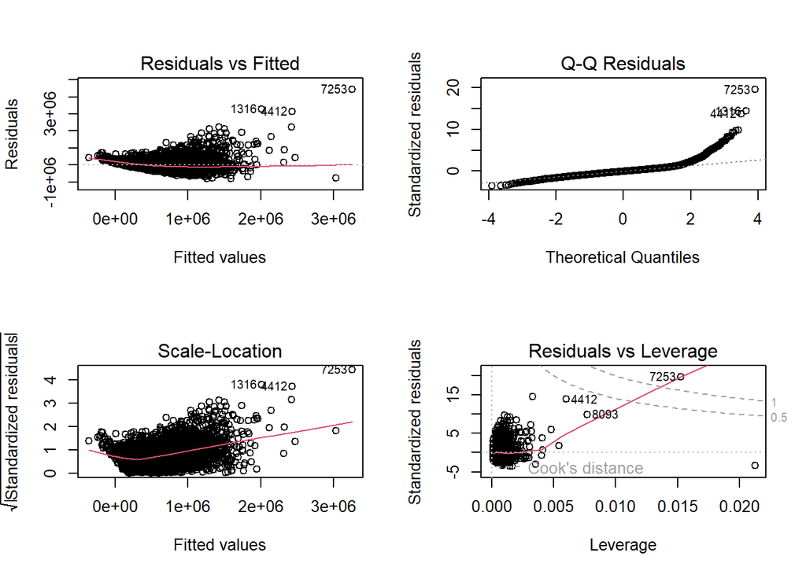

As with the other models, assumption 2 is not met. We will do a log transformation of the response and reevaluate.

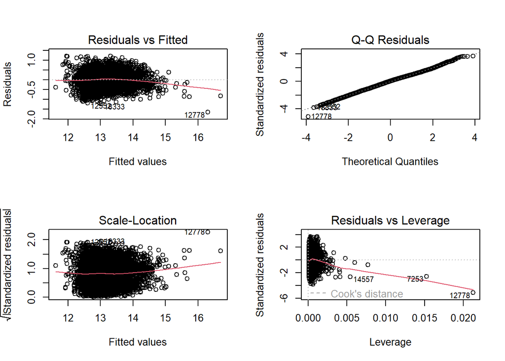

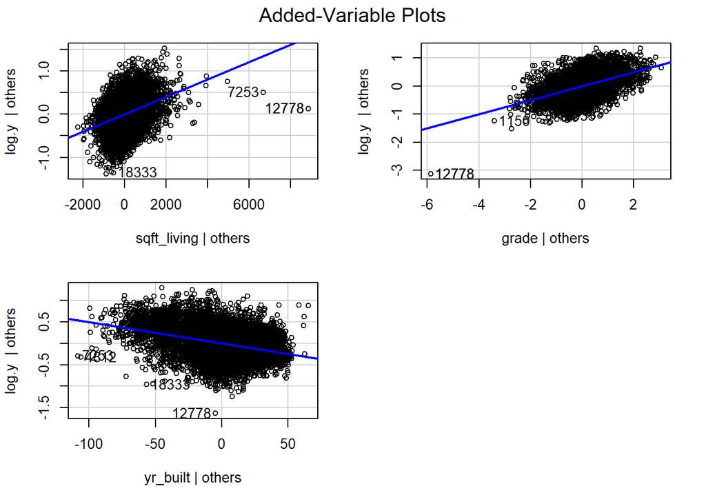

The *sqft_living* plot looks the least linear, so we will attempt a log transformation.

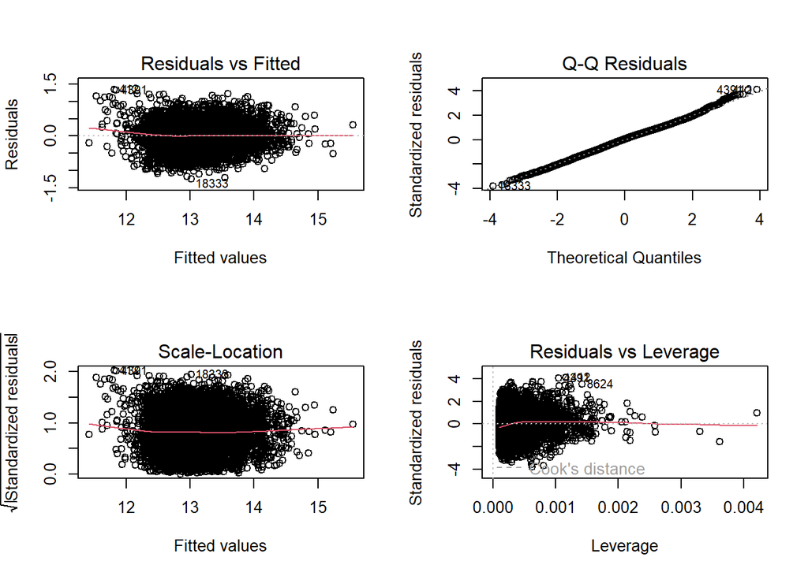

Both regression assumptions appear to be mostly met from looking at the residual plot, so we will now investigate the model compared to the others.

```
##
## Call:
## lm(formula = log.y ~ log.sqft + grade + yr_built, data = train_lin)
##
## Residuals:
##     Min      1Q  Median      3Q     Max
## -1.2392 -0.2205  0.0158  0.2174  1.3388
##
## Coefficients:
##               Estimate Std. Error t value Pr(>|t|)
## (Intercept) 18.3300736  0.2344164   78.19   <2e-16 ***
## log.sqft     0.4280280  0.0109437   39.11   <2e-16 ***
## grade        0.2591008  0.0041537   62.38   <2e-16 ***
## yr_built    -0.0053270  0.0001206  -44.19   <2e-16 ***
## ---
## Signif. codes:  0 '***' 0.001 '**' 0.01 '*' 0.05 '.' 0.1 ' ' 1
##
## Residual standard error: 0.3265 on 10802 degrees of freedom
## Multiple R-squared:  0.6148, Adjusted R-squared:  0.6147
## F-statistic:  5748 on 3 and 10802 DF,  p-value: < 2.2e-16
```

```
## Analysis of Variance Table
##
## Model 1: log.y ~ log.sqft + grade + yr_built
## Model 2: log.y ~ sqft_living
##   Res.Df    RSS Df Sum of Sq      F    Pr(>F)
## 1  10802 1151.7
## 2  10804 1567.5 -2   -415.85 1950.3 < 2.2e-16 ***
## ---
## Signif. codes:  0 '***' 0.001 '**' 0.01 '*' 0.05 '.' 0.1 ' ' 1
```

```
## Analysis of Variance Table
##
## Model 1: log.y ~ log.sqft + grade + yr_built
## Model 2: log.y ~ sqft_living + grade
##   Res.Df    RSS Df Sum of Sq    F    Pr(>F)
## 1  10802 1151.7
## 2  10803 1337.5 -1   -185.82 1743 < 2.2e-16 ***
## ---
## Signif. codes:  0 '***' 0.001 '**' 0.01 '*' 0.05 '.' 0.1 ' ' 1
```

All of the p-values are very significant, favoring keeping the 3 predictors in the model over the previous models or the intercept-only model.

```
## [1] "AIC model 3: 6482.49605508659"
```

```
## [1] "BIC model3: 6518.93533915861"
```

```
## [1] "MSE model3: 428612236161.135"
```

$log(price) = 18.3300736 + 0.4280280log(sqft_living) + 0.2591008grade - 0.0053270yr_built$

# Section 6: Question 2 data visualizations

### Univariate visualizaions

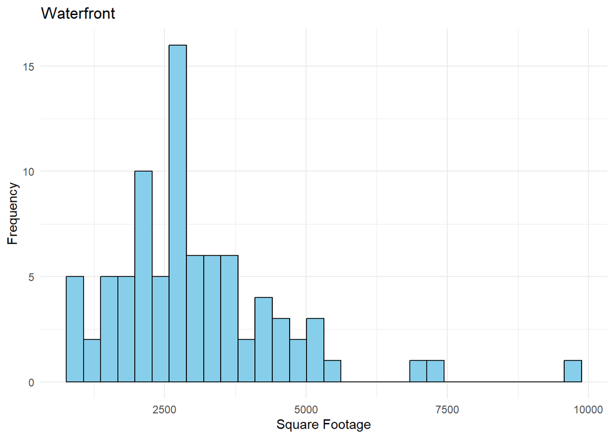

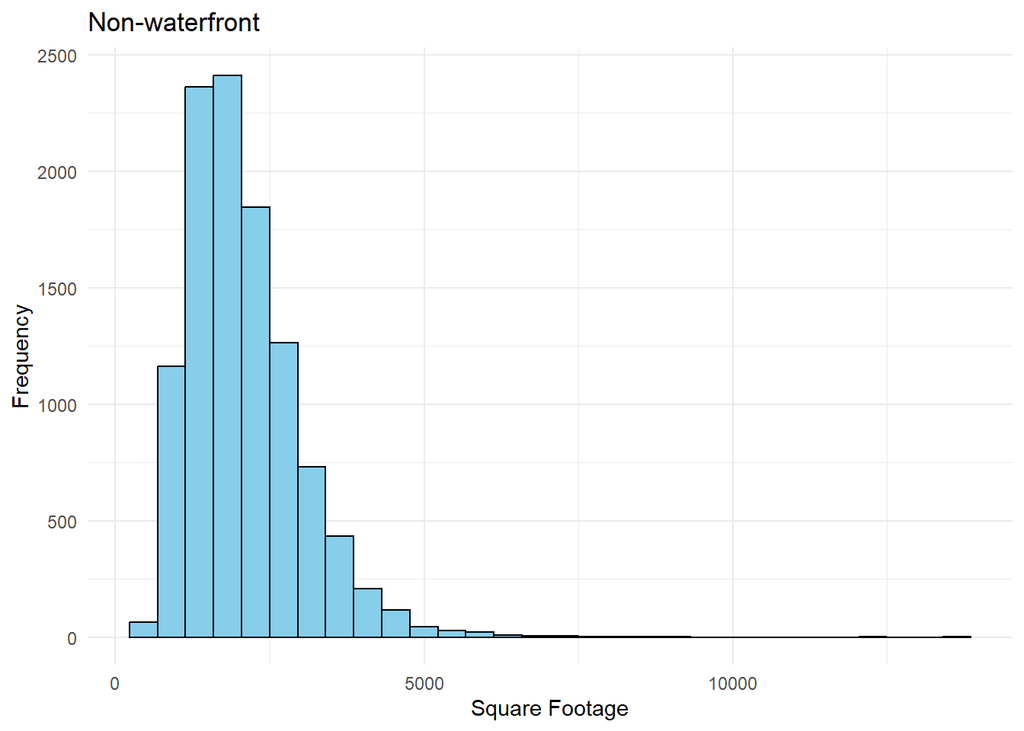

From the graphs, we can observe that the distribution of living area sizes for both waterfront and non-waterfront homes appears right-skewed, indicating that there are a larger number of homes with smaller living areas and fewer homes with larger living areas.

Waterfront homes are less frequent, which is expected since waterfront properties are typically rarer and potentially more desirable. It will be important to note the rarity of the waterfront status when choosing our threshold for logistic regression. The range of square footage for non-waterfront homes extends from the smallest to the largest sizes, showing a wide variety of home sizes. Waterfront homes tend to have larger living areas on average, with fewer small-sized homes compared to non-waterfront homes. There is a peak in frequency for non-waterfront homes at the smaller end of the scales. For waterfront homes, the data are more evenly distributed, although with a much lower frequency overall due to fewer waterfront homes in the dataset.

### Bivariate visualizations

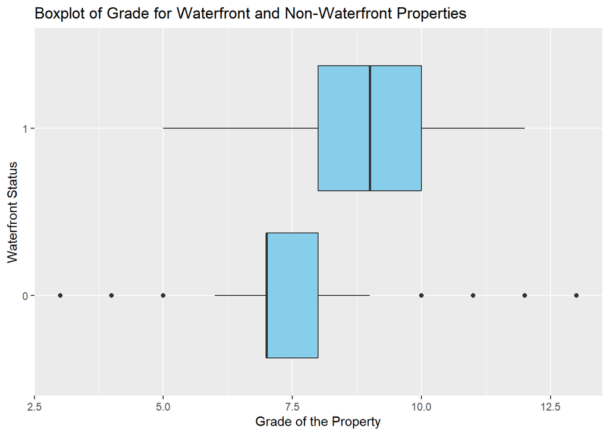

The x-axis for this visualization represents grade which for context indicates that 1-3 can be considered “poor construction” 7 has an average quality and 11-13 have a high quality. On the y-axis, the “1” group indicates that the property is waterfront while “0” indicates that it is not a waterfront property.

When examining the properties we note that waterfront properties tend to be fairly soundly made with a median score of approximately 9 and nothing within the poor construction range (<5). The boxplot is slightly skewed left, indicating a large number of high-quality homes. This is contrasted by non-waterfront properties which have 7 outliers and houses that are built to lower grades. The non-waterfront properties are skewed right, indicating a higher volume of lower-quality homes, with a median around 7. When we conduct the analysis we may wish to keep an eye out for the many outliers in the non-waterfront property category that may potentially skew the analysis.

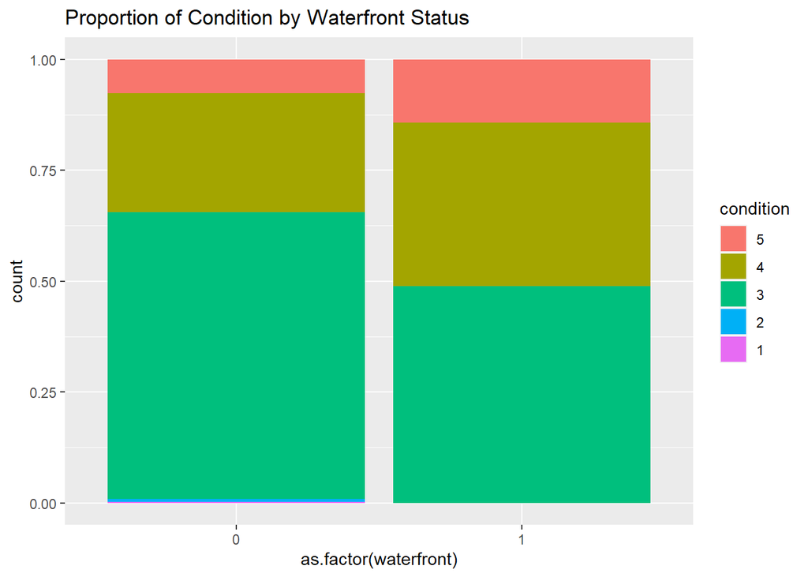

The bar graph demonstrates the trend wherein waterfront properties exhibit a higher prevalence of homes with higher condition ratings. About 50% of waterfront homes are rated condition 4 or 5, compared to only about 35% on non-waterfront properties.

Perhaps the proximity of these properties to bodies of water exposes them to heightened levels of humidity, salt, and other elemental factors. In response to these environmental stressors, property owners and builders may find it imperative to implement more stringent maintenance protocols. Such measures would be designed to mitigate the potential damage to the property’s siding or foundation, ultimately preserving the overall structural integrity of the house.

### Multivariate visualizations

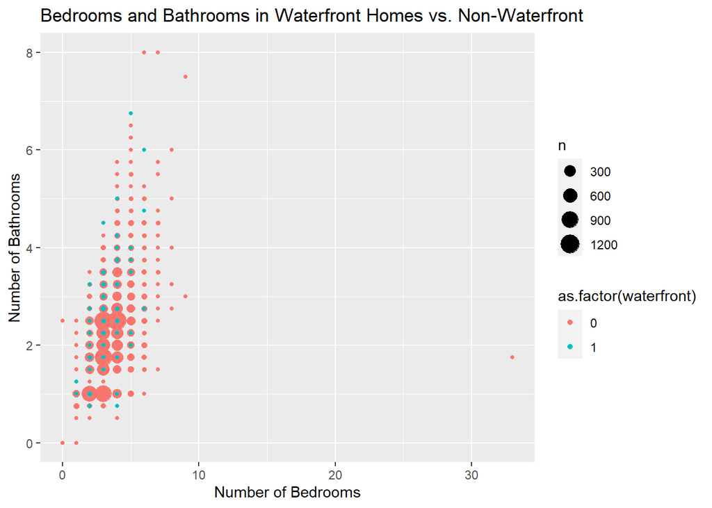

The scatterplot shows that most houses have 3-4 bedrooms and around 2 bathrooms. The blue points, representing waterfront properties, are evenly scattered throughout the rest of them, indicating that waterfront status may not be related to the number of bedrooms and bathrooms in a home. We notice a potentially influential observation in the lower-right quadrant of the graph, which represents a non-waterfront property with over 30 bedrooms but less than 2 bathrooms.

### Correlation matrix

```
##               waterfront bedrooms bathrooms sqft_living condition  grade
## waterfront         1.000   -0.013     0.064       0.090     0.033  0.081
## bedrooms          -0.013    1.000     0.505       0.563     0.028  0.349
## bathrooms          0.064    0.505     1.000       0.755    -0.127  0.660
## sqft_living        0.090    0.563     0.755       1.000    -0.059  0.756
## condition          0.033    0.028    -0.127      -0.059     1.000 -0.146
## grade              0.081    0.349     0.660       0.756    -0.146  1.000
## sqft_living15      0.085    0.384     0.571       0.754    -0.093  0.713
##               sqft_living15
## waterfront            0.085
## bedrooms              0.384
## bathrooms             0.571
## sqft_living           0.754
## condition            -0.093
## grade                 0.713
## sqft_living15         1.000
```

From the correlation matrix, waterfront appears to be only weakly correlated with any given predictor.

Predictor bedrooms has a moderate positive correlation with bathrooms and sqft_living. Predictor *bedrooms* has a weak positive correlation with *sqft_living15* and *grade*, while the correlation with *condition* is very weak. Predictor *bathrooms* has a strong positive correlation with *sqft_living* and *grade*, and a weak negative correlation with *condition.* Additionally, *sqft_living* has a strong positive correlation *grade* and *sqft_living15*, and grade is strongly correlated with *sqft_living15* as well.

Predictor *condition* overall has weak correlations with the other predictors.

# Section 7: Question 2 logistic regression

### Model selection

We use stepwise regression to help determine which model to use.

```
## Start:  AIC=985.33
## waterfront ~ 1
##
##                 Df Deviance    AIC
## + sqft_living15  1   924.00 928.00
## + grade          1   924.53 928.53
## + sqft_living    1   929.14 933.14
## + bathrooms      1   946.27 950.27
## + condition      1   972.63 976.63
## + bedrooms       1   981.19 985.19
## <none>               983.33 985.33
##
## Step:  AIC=928
## waterfront ~ sqft_living15
##
##                 Df Deviance    AIC
## + bedrooms       1   895.30 901.30
## + condition      1   906.17 912.17
## + grade          1   916.36 922.36
## + sqft_living    1   916.76 922.76
## + bathrooms      1   920.03 926.03
## <none>               924.00 928.00
## - sqft_living15  1   983.33 985.33
##
## Step:  AIC=901.3
## waterfront ~ sqft_living15 + bedrooms
##
##                 Df Deviance    AIC
## + sqft_living    1   866.47 874.47
## + bathrooms      1   874.06 882.06
## + condition      1   876.30 884.30
## + grade          1   882.86 890.86
## <none>               895.30 901.30
## - bedrooms       1   924.00 928.00
## - sqft_living15  1   981.19 985.19
##
## Step:  AIC=874.47
## waterfront ~ sqft_living15 + bedrooms + sqft_living
##
##                 Df Deviance    AIC
```

[output cut: 30 more lines]

```
## - condition      1   863.45 873.45
## - bedrooms       1   898.94 908.94
##
## Step:  AIC=853.69
## waterfront ~ sqft_living15 + bedrooms + sqft_living + condition +
##     bathrooms + grade
##
##                 Df Deviance    AIC
## <none>               839.69 853.69
## - grade          1   842.13 854.13
## - bathrooms      1   843.28 855.28
## - sqft_living    1   845.36 857.36
## - sqft_living15  1   848.52 860.52
## - condition      1   862.48 874.48
## - bedrooms       1   894.21 906.21
```

```
##
## Call:  glm(formula = waterfront ~ sqft_living15 + bedrooms + sqft_living +
##     condition + bathrooms + grade, family = binomial, data = train_log)
##
## Coefficients:
##   (Intercept)  sqft_living15       bedrooms    sqft_living      condition
##    -8.6275710      0.0005978     -1.2223204      0.0003997      0.7712262
##     bathrooms          grade
##     0.4100732      0.2172964
##
## Degrees of Freedom: 10805 Total (i.e. Null);  10799 Residual
## Null Deviance:       983.3
## Residual Deviance: 839.7     AIC: 853.7
```

We note the warning that fitted probabilities numerically 0 or 1 occurred, but hide them from the output because there are warnings for every model. As noted when examining the visualizations, waterfront properties can be considered a rare event.

Stepwise regression based on AIC suggests that the full model with all of the predictors best fits the data.

### Model 1: full model

We start by fitting the logistic regression model using all predictors because it was found to be the optimal model based on AIC stepwise regression.

```
##
## Call:
## glm(formula = waterfront ~ bedrooms + bathrooms + sqft_living +
##     condition + grade + sqft_living15, family = binomial, data = train_log)
##
## Coefficients:
##                 Estimate Std. Error z value Pr(>|z|)
## (Intercept)   -8.6275710  1.1088574  -7.781 7.22e-15 ***
## bedrooms      -1.2223204  0.1684267  -7.257 3.95e-13 ***
## bathrooms      0.4100732  0.2156360   1.902  0.05721 .
## sqft_living    0.0003997  0.0001629   2.453  0.01416 *
## condition      0.7712262  0.1526000   5.054 4.33e-07 ***
## grade          0.2172964  0.1387229   1.566  0.11725
## sqft_living15  0.0005978  0.0002011   2.973  0.00295 **
## ---
## Signif. codes:  0 '***' 0.001 '**' 0.01 '*' 0.05 '.' 0.1 ' ' 1
##
## (Dispersion parameter for binomial family taken to be 1)
##
##     Null deviance: 983.33  on 10805  degrees of freedom
## Residual deviance: 839.69  on 10799  degrees of freedom
## AIC: 853.69
##
## Number of Fisher Scoring iterations: 8
```

We perform a likelihood ratio test to assess the usefulness of our model compared to the intercept-only model.

$H_{0}: \beta_{1} = \beta_{2} = ... = \beta_{6} = 0$

$H_{a}:$ at least one of these is significant.

We find the test statistic by subtracting the Residual deviance from the null deviance: $G^{2} = 983.33 - 839.69 = 143.64

And compare it to a $\chi^{2}$ distribution with 6 degrees of freedom to find the p-value: $\chi^{2}_{143.64, 6} = 1.706419 \times e^{-28}$

Based on this highly significant p-value, we reject the null hypothesis. Our model fits the data better than the intercept-only model, i.e., at least some of our predictors are significantly useful.

```
##      bedrooms     bathrooms   sqft_living     condition         grade
##      273.7923      303.5891      245.4314      105.9845      288.6862
## sqft_living15
##      203.7323
```

The predictors have a high level of multicollinearity suggested by the high VIFs. A VIF over 10 indicates the predictors are highly correlated with other predictors, so it is likely that our model includes redundant predictors. We will use the values from the Wald Test and VIF scores to assess what predictors to drop.

Two reduced models were assessed.

### Model 2: bedrooms + sqft_living15 + condition

```
##
## Call:
## glm(formula = waterfront ~ bedrooms + sqft_living15 + condition,
##     family = binomial, data = train)
##
## Coefficients:
##                 Estimate Std. Error z value Pr(>|z|)
## (Intercept)   -7.8379287  0.7300426 -10.736  < 2e-16 ***
## bedrooms      -0.7914292  0.1464720  -5.403 6.54e-08 ***
## sqft_living15  0.0013924  0.0001328  10.487  < 2e-16 ***
## condition      0.6892260  0.1501176   4.591 4.41e-06 ***
## ---
## Signif. codes:  0 '***' 0.001 '**' 0.01 '*' 0.05 '.' 0.1 ' ' 1
##
## (Dispersion parameter for binomial family taken to be 1)
##
##     Null deviance: 983.33  on 10805  degrees of freedom
## Residual deviance: 876.30  on 10802  degrees of freedom
## AIC: 884.3
##
## Number of Fisher Scoring iterations: 8
```

We conduct a hypothesis test to compare model 2 to model 1

$H_{0}: \beta_{2} = \beta_{3} = \beta_{5} = 0$

$H_{a}:$ at least one of these is significant.

Test statistic: $\Delta G^{2} = 876.30 - 839.69 = 36.61$

p-value: $\chi^{2}_{36.61, 3} = 5.551257 \times e^{-08}$

Based on the significant p-value, we reject the null hypothesis. The likelihood ratio test favors the full model.

### Model 3: bedrooms + sqft_living + condition

The second reduced model we investigate keeps *sqft_living* instead of *sqft_living15.*

```
##
## Call:
## glm(formula = waterfront ~ bedrooms + sqft_living + condition,
##     family = binomial, data = train_log)
##
## Coefficients:
##               Estimate Std. Error z value Pr(>|z|)
## (Intercept) -6.037e+00  6.782e-01  -8.901  < 2e-16 ***
## bedrooms    -1.079e+00  1.555e-01  -6.944 3.81e-12 ***
## sqft_living  1.007e-03  9.165e-05  10.984  < 2e-16 ***
## condition    6.518e-01  1.497e-01   4.354 1.34e-05 ***
## ---
## Signif. codes:  0 '***' 0.001 '**' 0.01 '*' 0.05 '.' 0.1 ' ' 1
##
## (Dispersion parameter for binomial family taken to be 1)
##
##     Null deviance: 983.33  on 10805  degrees of freedom
## Residual deviance: 865.49  on 10802  degrees of freedom
## AIC: 873.49
##
## Number of Fisher Scoring iterations: 8
```

$H_{0}: \beta_{2} = \beta_{5} = \beta_{6} = 0$

$H_{a}:$ at least one of these is significant.

Test statistic: 865.49 - 839.69 = 25.80$

p-value: $\chi^{2}_{25.80, 3} = 1.049799 \times e^{-05}$

Based on the significant p-value, we reject the null hypothesis. The likelihood ratio test favors the full model. We will keep model 1 with all predictors.

### Confusion Matrices

```
##
##     FALSE  TRUE
##   0 10727     1
##   1    79     0
```

```
##
##     FALSE  TRUE
##   0 10558   170
##   1    66    13
```

The confusion matrices provide insights into the model’s performance at different probability thresholds. At the threshold of 0.5, the model predicts only one property to be a waterfront property, resulting in false negatives for all 79 properties which are actually waterfront.

By lowering the probability threshold to 0.05, the model becomes more sensitive: the sensitivity increases from zero to 16.46%, while the accuracy of the model is reduced from 99.26% to 97.82%. This is a trade-off between capturing more waterfront properties correctly at the expense of introducing more false positives.

Overall this could be a result of the skewed nature of the data set.

### ROC and AUC

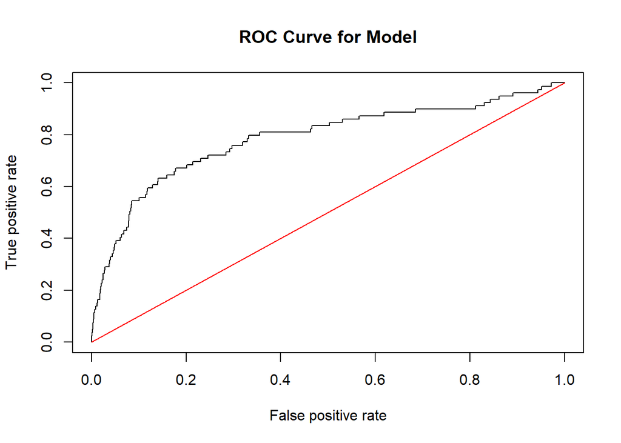

Based on the ROC curve for model 1, the model performs better than random guessing because the curve is above the diagonal, which represents random guessing.

```
## [[1]]
## [1] 0.7853352
```

The calculated AUC value for the model is 0.7853352. In conjunction with the ROC, the high AUC value indicating that the model performs significantly better than random random guessing. We will keep all of the predictors in our final model.

### Estimated Logistic Regression Equation

```
##                    Estimate   Std. Error   z value     Pr(>|z|)
## (Intercept)   -8.6275710459 1.1088573763 -7.780596 7.218378e-15
## bedrooms      -1.2223204021 0.1684267035 -7.257284 3.949403e-13
## bathrooms      0.4100731864 0.2156359564  1.901692 5.721142e-02
## sqft_living    0.0003997073 0.0001629428  2.453053 1.416493e-02
## condition      0.7712262326 0.1526000136  5.053907 4.328631e-07
## grade          0.2172963650 0.1387229022  1.566406 1.172536e-01
## sqft_living15  0.0005978207 0.0002011069  2.972651 2.952401e-03
```

$logit(waterfront) = −8.628 + 0.0003997sqft_living − 1.222bedrooms + 0.410bathrooms + 0.0005978sqft_living15 + 0.771condition + 0.217grade$

Interpretations of the Coefficients:

When the predictors are zero, the estimated log-odds of the property having a waterfront view is -8.628.

For each additional sqaure foot increase in living space, the estimated log-odds of the property having a waterfront view increases by 0.0003997, while controlling for the other predictors.

For each additional bedroom, the estimated log-odds of the property having a waterfront view decreases by 1.222 while controlling for the other predictors.

For each additional bathroom, the estimated log-odds of the property having a waterfront view increases by 0.410 while controlling for the other predictors.

For each additional square foot living area of the nearest 15 neighbors, the estimated log-odds of the property having a waterfront view increase by 0.0005978 while controlling for other predictors.

For one unit increase in condition (1-5 scale), the estimated log-odds of the property having a waterfront view increases by 0.771 while controlling for the other predictors.

For one unit increase in grade, the estimated log-odds of the property having a waterfront view increases by 0.217 while controlling for other predictors.